# report_2403967

## Countering COVID with The Best Stratergy

Khawaja Muhhammad Saad Butt - 2403967b

University of Glasgow

## Abstract

> COVID-19 has been an epidemic which took the world by storm and has had it's svere consequences. Governemnts across the world had taken restrictive measures and in this report/assessed exercise I will present one of the optimal stratergies which the Governemnts can take to counter the COVID-19 problem. The report demonstrate how and which stratergy should the Government opt for and how would it impact the entire year in terms of COVID situation. To figure out such a policy, the code below demonstrates different agents that have been implemented along with their evaluation.

```python
# Obtain the notebook JSON as a string
from google.colab import _message
notebook_json = _message.blocking_request('get_ipynb', request='', timeout_sec=10)

# collate all text in Markdown cells
all_text = ''
for cell in notebook_json['ipynb']['cells']:
    if cell['cell_type'] == "markdown":
        all_text += ' '.join(cell['source'])
# replace # and \n by empty space
all_text = all_text.replace('#', '').replace('\n', '')
# find main section and reference & appendix section
before_eof, eof, after_eof = all_text.partition('===EOF===') # please do not temper with this

# count words per section, our counting method is simple and probably plays in your favor
report_word_count = len(before_eof.split())
remaining_word_count = len(after_eof.split())

print("Your report currently has {} words".format(report_word_count))
print("Your reference and appendix currently have {} words".format(remaining_word_count))

# Please respect this convention and work with it, not against it.
# We will run an independant word count check on all notebooks submitted
```

```
Your report currently has 4828 words
Your reference and appendix currently have 377 words
```

# 1. Introduction

> Your mission is to design, implement, evaluate and document a number of virtual agents which can learn (optimal) COVID-19 mitigation policies.

## 1.1 Motivation

> COVID-19 has been an epidemic which took the world by storm and has had it's svere consequences. Governemnts across the world had taken restrictive measures and in this report/assessed exercise I will present one of the optimal stratergies which the Governemnts can take to counter the COVID-19 problem.

> To demonstrate the stratergies the Governments can take and the impact they would have on the the COVID situation is presented below and later evaluated to show it's success.

> Such an optimaml policy can be implemented by the some latest algortihm such Reinforcement Learning which is explored in the report below with comparison of Diterministic agents and Rnadom agent.

## 1.2 Task Environment

> ViRL is an environment which would be our main course of attention. ViRL is an Epidemics Reinforcement Learning Environment which helps in exploring the several policies that help to reduce the spread of COVID-19 virus.

> ViRL is available at https://git.dcs.gla.ac.uk/SebastianStein/virl, the readme gives more information about the environment.

> External libraries, like ViRL, can be installed directly from inside the notebook as follow:

```python
!git clone https://git.dcs.gla.ac.uk/SebastianStein/virl.git
```

```
fatal: destination path 'virl' already exists and is not an empty directory.
```

> Once cloned from GitLab, you can add the virl folder to the path where Python can look for libraries (sys.path)

```python
## to import virl, we add the virl folder cloned above to the path where Python can look for libraries (sys.path)
import sys
sys.path.append('virl')
import virl
```

> The ViRL library can now be used directly from this notebook

> The are all the libraries required to solve the assessed exercise

## Note: Usually the first run, the imports will cause an error. In that case, please restart runtime and then run it again. That will fix it.

```python
from matplotlib import pyplot as plt
import numpy as np
import random
import numpy as np
import tensorflow as tf
from tensorflow import keras
from tensorflow.keras import layers

from tensorflow.keras.models import Sequential
from tensorflow.keras.layers import Dense
from tensorflow.keras.optimizers import Adam
from tensorflow.keras import backend as K

import matplotlib.pyplot as plt
import time
import itertools
import matplotlib
from mpl_toolkits.mplot3d import Axes3D
from collections import deque
import pandas as pd
import statistics

import numpy as np
import sys
import os
import random
from collections import namedtuple
import collections
import copy

!pip install tensorflow==1.14.0
!pip install keras==2.2.4
```

> The ViRL proposes 4 non-medical policy interventions for the agents that are entrusted to be controlling the spread of the COVID-19 virus.
> 1. no intervention (remove all restrictions)
> 2. impose a full lockdown
> 3. implement track & trace
> 4. enforce social distancing and face masks

> After running each episode for 52 weeks, the agent makes a decision to take based on the evidence obtained from the state of the epidemic as the number of persons that are:
> 1. susceptibles
> 2. infectious
> 3. quarantined
> 4. recovereds

>

> Every interference can affect the infection rate dissimilarly (the number of concurrently infected and hospitalized persons) and on the economic opportunity cost (summarized single scalar reward at each time step).

>

> Relationship between the reward and the state of epidemic are hard coded into the simulator, using a bunch of parameters which make the simulation possible. The reward values are presented in negative float number, and the sum of all the rewards are then compared to check whether the outcome was optimal or not. The higher the reward vlaue, the better the outcome.

> Below is an example of running an dummy agent on the ViRL environment. This agent will always take the same action every week, irrespectively of the current state of the population.

```python
env = virl.Epidemic()

states = []
rewards = []
done = False

s = env.reset() # reset the environment before using it and log the starting state
states.append(s)
while not done:
    s, r, done, i = env.step(action=0) # deterministic agent doing action 0 (no-intervention)
    states.append(s)
    rewards.append(r)
```

> As a example, you can now plot the evolution of states and reward for the 52 weeks of this epidemic simulation.

```
Total reward for this episode is  -1.9231823993453754
```

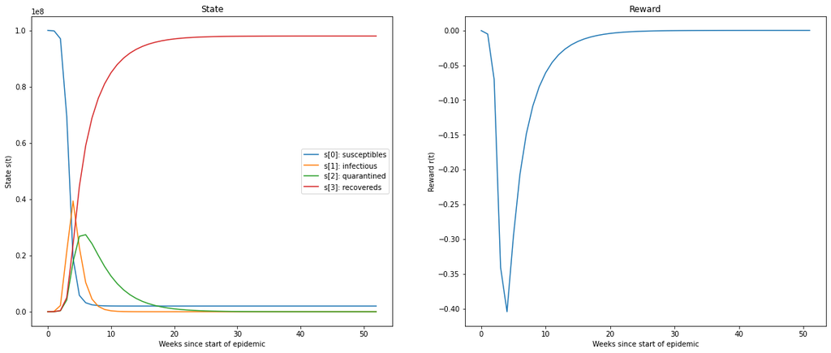

```python
# start a figure with 2 subplot
fig, axes = plt.subplots(1, 2, figsize=(20, 8))
labels = ['s[0]: susceptibles', 's[1]: infectious', 's[2]: quarantined', 's[3]: recovereds']
states = np.array(states)

# plot state evolution on the left subplot
for i in range(4):
    axes[0].plot(states[:,i], label=labels[i]);
axes[0].set_title('State')
axes[0].set_xlabel('Weeks since start of epidemic')
axes[0].set_ylabel('State s(t)')
axes[0].legend()

# plot reward evolution on the right subplot
axes[1].plot(rewards);
axes[1].set_title('Reward')
axes[1].set_xlabel('Weeks since start of epidemic')
axes[1].set_ylabel('Reward r(t)')

print('Total reward for this episode is ', np.sum(rewards))
```

> It can be seen in the graoh how this policy creates an overflow of cases at the start of the epidemic as the reward value goes very low in the first weeks. Later, as the patients start to recover the graphs goes back up to low negative value.

# 1.3 PEAS Anlysis

> The following presents the PEAS analysis for our problem

## Performance Measure

- Rewards

*Closer to the zero, the better the rewards*

## Environment

- ViRL

*Epidemics Reinforcement Learning Environment*

## Action

> The Virtual environment ViRL takes these 4 actions and implements a policy:
- [0]no intervention (remove all restrictions)
- [1]impose a full lockdown
- [2]implement track & trace
- [3]enforce social distancing and face masks

## Sensor

- [0]susceptibles
- [1]infectious
- [2]quarantined
- [3]recovereds

# 2. Method and Implementation

> In this experiment we'll implement three different types of agents named Random, Determinsitc, and Q-Learning with Neural Netwrok Function Approximation where we'll compare their rewards and see how each agent performed in comparison to the other.

## 2.1 Random Agent

> The Random agent simple takes a random action from env.action_space.n and returns it to the en.step(). Env.step() then performs action for the step passed by the random agent and appends to the state and rewards denoted by the action for the current week. This process is repeated in the same manner for the next 52 weeks.

```
-2.305388877560294
Total reward for this episode is  -2.3053888775602944
```

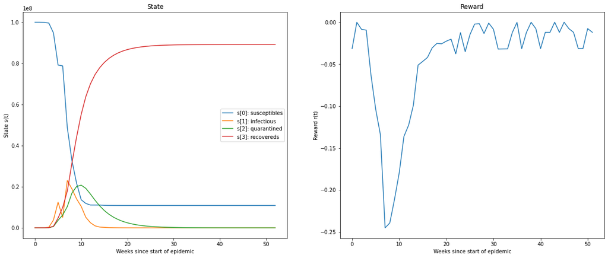

```python
# add code for your random agent

def random_agent(s):
  action = np.random.choice(env.action_space.n)
  return action

env = virl.Epidemic()

R_states = []
R_rewards = []
R_action = []
done = False

s = env.reset()
R_states.append(s)


while not done:
      action = random_agent(s)
      s, r, done, i = env.step(action=action)
      R_action.append(action)
      R_states.append(s)
      R_rewards.append(r)



print(sum(R_rewards))

fig, axes = plt.subplots(1, 2, figsize=(20, 8))
labels = ['s[0]: susceptibles', 's[1]: infectious', 's[2]: quarantined', 's[3]: recovereds']
states = np.array(R_states)

# plot state evolution on the left subplot
for i in range(4):
    axes[0].plot(states[:,i], label=labels[i]);
axes[0].set_title('State')
axes[0].set_xlabel('Weeks since start of epidemic')
axes[0].set_ylabel('State s(t)')
axes[0].legend()

# plot reward evolution on the right subplot
axes[1].plot(R_rewards);
axes[1].set_title('Reward')
axes[1].set_xlabel('Weeks since start of epidemic')
axes[1].set_ylabel('Reward r(t)')

print('Total reward for this episode is ', np.sum(R_rewards))
```

## 2.2 Deterministic Agent

> Deterministic agent is an agent where the current state and the selected action of the agent can fully decide the next state of the environment. In deterministc, the agent doesn't need to worry about unpredictability.

> Following is a code presented where a determministic agent is implemented where it access the 4 actions of the environment, compares them to a certain number of the pateints either suspected, infected, recovered or infectious and then determines a action which is suppose to be implemented.

> In our case, the suspecticles greater than 5000000, infectious greater than 10000, quarantine greater than 300000 and recovered greater than 500000 then action "impose full lock down" would be implemeted. Otherwise track and trace down would be implemented.

```python
def deterministic_agent(s):
  action = 0
  if s[0] > 5000000 and s[1] > 10000 and s[2] > 300000 and s[3] > 500000:
    action = 1
  else:
    action = 2
  return action
```

```python
# test deterministic agent on default environment
env = virl.Epidemic()

D_states = []
D_rewards = []
D_action = []

done = False

s = env.reset()
D_states.append(s)
while not done:
    action = deterministic_agent(s)
    D_action.append(action)
    s, r, done, i = env.step(action=action)
    D_states.append(s)
    D_rewards.append(r)
print(sum(D_rewards))
```

```
-1.209125303870942
```

```python
'''
# start a figure with 2 subplot
fig, axes = plt.subplots(1, 2, figsize=(20, 8))
labels = ['s[0]: susceptibles', 's[1]: infectious', 's[2]: quarantined', 's[3]: recovereds']
states = np.array(D_states)

# plot state evolution on the left subplot
for i in range(4):
    axes[0].plot(states[:,i], label=labels[i]);
axes[0].set_title('State')
axes[0].set_xlabel('Weeks since start of epidemic')
axes[0].set_ylabel('State s(t)')
axes[0].legend()

# plot reward evolution on the right subplot
axes[1].plot(D_rewards);
axes[1].set_title('Reward')
axes[1].set_xlabel('Weeks since start of epidemic')
axes[1].set_ylabel('Reward r(t)')
print('Total reward for this episode is ', np.sum(D_rewards))
'''
```

[output not shown]

## 2.3 Q-Learning with Function Approximation

> Q-Learning is an reinforcement algorithm that looks to find the most suitable action for every given state. Q-learninng is said to be an off policy RL algorithm as it learns from actions which are not in the current policy. Basically, q-learnings looks forward to learn a policy whihch would maximzie the rewards [1].

> As our third agent, is going to be a Q-Learning with Function Approximization which would use neural network. For each episode, the agent takes an action (either the maximum reawrd from the Q-Table or randomly), then observes the reward of the action chosen to update the temporal difference of Q-table using the formula (AIMA, page 844):

> `𝑸(𝒔,𝒂)←𝑸(𝒔,𝒂)+𝜶[𝑹(𝒔)+𝜸 𝒎𝒂𝒙𝒂′ 𝑸(𝒔′,𝒂′)−𝑸(𝒔,𝒂)]`

> Where:
- R(s) : reward
- Q(s,a): final action value after state s and action a
- s' : next state
- s : current state
- a : current action (lockdown, restrictions etc)
- a' : next action
- y : discount factor from 0 to 1
- α : learning effect from 0 to 1

> A major problem when naively applying neural network is that they tend to overfit quite badly (due to the flexibility) which is especially the case in RL where the observation are highly correlated (due to the sequential behavior and nature of the policy). In order to break this correlation (within a single update) we implement a so-called replay buffer which saves all observation for a certain period back in time. We then sample from this buffer when making our updates. Below we implement such a buffer.

> RL observations are highly correlated (because of the policy's nature and sequential beahviour). In order to interrupt the correlation , replay buffer is implemented which saves observations for a brief history in time. After that, we sample this buffer when making the updates.

> Finally our model is implement and our reinforcement learning agent that every week takes an action based on its experience from playing against the simulator for hundreds of training episodes. The Q-learning agent bascially follows a policy and update the function approximator.

> Later in your report,the agent is trained and reported how it learns and how it performs on the ViRL simulator.

# NOTE:

The following code is taken Lab 8 solutions

```python
class NNFunctionApproximatorJointKeras():
    """ A basic MLP neural network approximator and estimator using Keras
    """

    def __init__(self, alpha, d_states, n_actions, nn_config, verbose=False):
        self.alpha = alpha
        self.nn_config = nn_config      # determines the size of the hidden layer (if any)
        self.n_actions = n_actions
        self.d_states = d_states
        self.verbose=verbose # Print debug information
        self.n_layers = len(nn_config)
        self.model = self._build_model()

    def _huber_loss(self,y_true, y_pred, clip_delta=1.0):
        """
        Huber loss (for use in Keras), see https://en.wikipedia.org/wiki/Huber_loss
        The huber loss tends to provide more robust learning in RL settings where there are
        often "outliers" before the functions has converged.

        Note: There i sa huber loss which is likely quicker, but we want to show you the core implementation here
        """
        error = y_true - y_pred
        cond  = K.abs(error) <= clip_delta
        squared_loss = 0.5 * K.square(error)
        quadratic_loss = 0.5 * K.square(clip_delta) + clip_delta * (K.abs(error) - clip_delta)
        return K.mean(tf.where(cond, squared_loss, quadratic_loss))

    def _build_model(self):
        # Neural Net for Deep-Q learning
        model = Sequential()
        for ilayer in self.nn_config:
            model.add(Dense(ilayer, input_dim=self.d_states, activation='relu'))
        model.add(Dense(self.n_actions, activation='linear'))
        model.compile(loss=self._huber_loss, # define a special loss function
                      optimizer=Adam(lr=self.alpha, clipnorm=10.)) # specify the optimiser, we clip the gradient of the norm which can make traning more robust
        return model

    def predict(self, s, a=None):
        if a==None:
            return self._predict_nn(s)
        else:
            return self._predict_nn(s)[a]

    def _predict_nn(self,state_hat):
        """
        Predict the output of the neural netwwork (note: these can be vectors)
        """
        x = self.model.predict(state_hat)
        return x

    def update(self, states, td_target):
        self.model.fit(states, td_target, epochs=1, verbose=0) # take one gradient step usign the optimiser
        return
```

```python
Transition = namedtuple('Transition',
                        ('state', 'action', 'next_state', 'reward','is_not_terminal_state'))

class ReplayMemory():
    """
    Implement a replay buffer using the deque collection
    """

    def __init__(self, capacity):
        self.capacity = capacity
        self.memory = deque(maxlen=capacity)

    def push(self, *args):
        """Saves a transition."""
        self.memory.append(Transition(*args))

    def pop(self):
        return self.memoery.pop()

    def sample(self, batch_size):
        return random.sample(self.memory, batch_size)

    def __len__(self):
        return len(self.memory)
```

```python
# Note: This a an inline implementation for teaching purposes (you may want
# to split you own "production" code into more smaller parts" and optimise the performance!)

# Keep track of some stats
EpisodeStats = namedtuple("Stats",["episode_lengths", "episode_rewards"])

# Main Q-learner
def q_learning_nn(env, func_approximator, func_approximator_target, num_episodes,max_steps_per_episode=500,discount_factor=0.95, epsilon_init=0.01, epsilon_decay=0.99995,epsilon_min=0.01,use_batch_updates=True, show=False, fn_model_in=None, fn_model_out=None):
    """
    Q-Learning algorithm for Q-learning using Function Approximations.
    Finds the optimal greedy policy while following an explorative greedy policy.

    Args:
        env: OpenAI environment.
        func_approximator: Action-Value function estimator, behavior policy (i.e. the function which determines the next action)
        func_approximator_target: Action-Value function estimator, updated less frequenty than the behavior policy
        num_episodes: Number of episodes to run for.
        max_steps_per_episode: Max number of steps per episodes
        discount_factor: Gamma discount factor.
        epsilon_init: Exploration strategy; chance the sample a random action. Float between 0 and 1.
        epsilon_decay: Each episode, epsilon is decayed by this factor
        epislon_min: Min epsilon value
        use_batch_updates=True,
        show: Render the environment (mainly for test/demo)
        fn_model_in: Load the model from the file if not None
        fn_model_out: File name of the saved model, saves the best model in the last 100 episodes

    Returns:
        An EpisodeStats object with two numpy arrays for episode_lengths and episode_rewards.
    """

    memory = ReplayMemory(BUFFER_SIZE) # init the replay memory
    n_actions = env.action_space.n
    d_states  = env.observation_space.shape[0]
    best_reward = 0
    Q_action = []

    # Synch the target and behavior network
    if not fn_model_in is None:
        func_approximator.model.load_weights(fn_model_in)
    func_approximator_target.model.set_weights(func_approximator.model.get_weights())

    # Keeps track of useful statistics
    stats = EpisodeStats(
        episode_lengths=np.zeros(num_episodes),
        episode_rewards=np.zeros(num_episodes))

    epsilon = epsilon_init
    states = np.zeros(shape=(2500,4)) # Should match the number of episodes
    for i_episode in range(num_episodes):
        sys.stdout.flush()
        # Reset the environment and pick the first action
        state = env.reset()
        state = np.reshape(state, [1, d_states]) # reshape to the a 1xd_state numpy array

        # One step in the environment
        for t in range(max_steps_per_episode):#itertools.count():
             #
            if(show):
                env.render()

            # Select an action usign and epsilon greedy policy based on the main behavior network
            if np.random.rand() <= epsilon:
                action = random.randrange(n_actions)
            else:
                act_values = func_approximator.predict(state)[0]
                action = np.argmax(act_values)  # returns action

            # Take a step
            next_state, reward, done, _ = env.step(action)

            next_state = np.reshape(next_state, [1, d_states] )

            # Add observation to the replay buffer
            if done:
                memory.push(state, action, next_state, reward, 0.0)
            else:
                memory.push(state, action, next_state, reward, 1.0)

            # Update statistics
            stats.episode_rewards[i_episode] += reward
            stats.episode_lengths[i_episode] = t

            #print(done)
            #print(len(memory))
            #print(func_approximator.alpha)
            #print()
            # Update network (if learning is on, i.e. alpha>0 and we have enough samples in memory)
            if func_approximator.alpha > 0.0 and len(memory) >= BATCH_SIZE:

                # Fetch a bacth from the replay buffer and extract as numpy arrays
                transitions = memory.sample(BATCH_SIZE)
                batch = Transition(*zip(*transitions))
                train_rewards = np.array(batch.reward)
                train_states = np.array(batch.state)
                train_next_state = np.array(batch.next_state)
                train_actions = np.array(batch.action)
                train_is_not_terminal_state = np.array(batch.is_not_terminal_state) #

                if(use_batch_updates):
                    # Do a single gradient step computed based on the full batch
                    train_td_targets    = func_approximator.predict(train_states.reshape(BATCH_SIZE,4)) # predict current values for the given states
                    q_values_next       = func_approximator_target.predict(np.array(batch.next_state).reshape(BATCH_SIZE,d_states))
                    train_td_targetstmp = train_rewards + discount_factor * train_is_not_terminal_state * np.amax(q_values_next,axis=1)
                    train_td_targets[ (np.arange(BATCH_SIZE), train_actions.reshape(BATCH_SIZE,).astype(int))] = train_td_targetstmp
                    func_approximator.update(train_states.reshape(BATCH_SIZE,d_states), train_td_targets) # Update the function approximator using our target
                else:
                    # Do update in a truely online sense where a gradient step is performaed per observation
                    for s in range(train_rewards.shape[0]):
                        target = func_approximator.predict(train_states[s])[0]
                        q_next = func_approximator_target.predict(train_next_state[s])[0]
                        target[train_actions[s]] = train_rewards[s] + discount_factor * train_is_not_terminal_state[s] * np.amax(q_next)
                        func_approximator.update(train_states[s], target.reshape(1,n_actions)) # Update the function approximator using our target
                if epsilon > epsilon_min:

                    epsilon *= epsilon_decay

            state = next_state
            states[i_episode] = state
            Q_action.append(action)
            '''
            # Synch the target and behavior network
            func_approximator_target.model.set_weights(func_approximator.model.get_weights())

            print("\repisode: {}/{}, score: {}, epsilon: {:.2}".format(i_episode, num_episodes, reward, epsilon), end="")

            # Save the best model so far
            if fn_model_out is not None and (t >= best_reward):
                func_approximator.model.save_weights(fn_model_out)
                best_reward = t
            '''

            if done:
                # Synch the target and behavior network
                func_approximator_target.model.set_weights(func_approximator.model.get_weights())

                print("\repisode: {}/{}, score: {}, epsilon: {:.2}".format(i_episode, num_episodes, t, epsilon), end="")

                # Save the best model so far
                if fn_model_out is not None and (t >= best_reward):
                    func_approximator.model.save_weights(fn_model_out)
                    best_reward = t

                break
    return stats,states,Q_action
```

> The learning rate, which is the leap the code takes to find out the optimal policy, is chosen to low (0.000001) and the discount factor equal to 0.95 whihch helps in producing high rewards for our Q-learning model. The batch size is chosen to be 64 and initial epsilon value is 0.1 and can go to a max low of 0.01 with a decay rate of 0.9995. The epsilon value dictates the randomness is finding specific actions base on the Q values we already have. The max_iter per epsisode is 52 which makes sure our env.action() returns a true in our done varaible (episode reaching to it's conclusion).

> As per to encapsulate the reward value, I selected the last value in our list of rewards value beacuse once the graph converges, the last value reflect the approximate reward value which shows convergence. So from here all the reward values being compared and analysed for Q-Learning are basically the last values as depicted from the graph.

```python
env = virl.Epidemic()
d_states    = env.observation_space.shape[0]
n_actions   = env.action_space.n

alpha= 0.000001
nn_config   = [64,64]
BATCH_SIZE  = 64
BUFFER_SIZE = 10000
```

```python
# Init the two networks
nn_func_approximator = NNFunctionApproximatorJointKeras(alpha, d_states, n_actions, nn_config)
nn_func_approximator_target = NNFunctionApproximatorJointKeras(alpha, d_states, n_actions, nn_config)
```

[output not shown]

```python
stats,Q_states,Q_action = q_learning_nn(env,nn_func_approximator, nn_func_approximator_target,num_episodes= 2000, max_steps_per_episode=52,
                      epsilon_init=0.1, epsilon_decay=0.9995, epsilon_min=0.01, fn_model_in=None, fn_model_out="q-learning.tf")
```

```
episode: 1999/2000, score: 51, epsilon: 0.01
```

```python
Q_rewards = stats[1]
print(Q_rewards[-1])
```

```
-1.8027501501904744
```

```python
env.close()
```

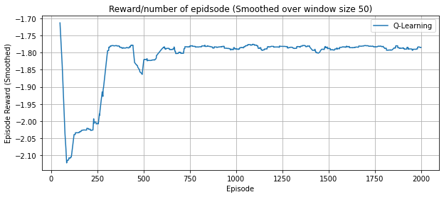

```python
def plot_episode_stats(stats0, smoothing_window):
    # Plot the episode reward over time

    fig2 = plt.figure(figsize=(10,4))
    rewards_smoothed0 = pd.Series(stats0).rolling(smoothing_window, min_periods=smoothing_window).mean()

    plt.plot(rewards_smoothed0, label = 'Q-Learning')

    plt.xlabel("Episode")
    plt.ylabel("Episode Reward (Smoothed)")
    plt.title("Reward/number of epidsode (Smoothed over window size {})".format(smoothing_window))
    plt.grid(True)
    plt.legend()
plot_episode_stats(Q_rewards, smoothing_window=50)
```

# 3. Results

> After running our models and testing them for reward values, now in this section I will evaluate our agents on three different versions of ViRL environments where we will plot our graphs to show the results.

## 3.1 Evaluation metrics

> After designing our agents and training our q-learning model, in this section we'll evalutate how our model performs by providing different graphs and statsitics for it. To document the behaviour of our agents we will plot graphs relating to the metrics such as average rewards against number of episodes, rewards varying for every week till the end of year and what action were taken for what rewards according to each agent.These metrics will help us identify which agent is better at which situation and which should we avoid at all times.

>

```python
def subplot(states, rewards, agent):
  fig, axes = plt.subplots(1, 2, figsize=(15, 4))
  labels = ['s[0]: susceptibles', 's[1]: infectious', 's[2]: quarantined', 's[3]: recovereds']
  states = np.array(states)

  # plot state evolution on the left subplot
  for i in range(4):
      axes[0].plot(states[:,i], label=labels[i]);
  axes[0].set_title('State')
  axes[0].set_xlabel('Weeks since start of epidemic')
  axes[0].set_ylabel('State s(t)')
  axes[0].legend()

  # plot reward evolution on the right subplot
  axes[1].plot(rewards, label=agent);
  axes[1].set_title('Reward')
  axes[1].set_xlabel('Weeks since start of epidemic')
  axes[1].set_ylabel('Reward r(t)')
```

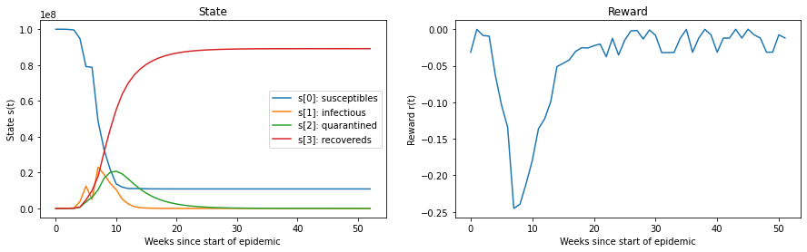

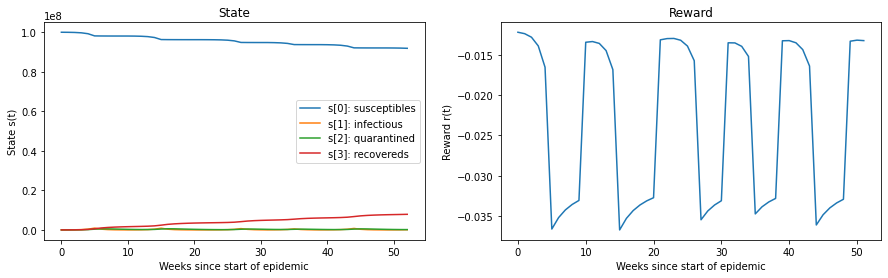

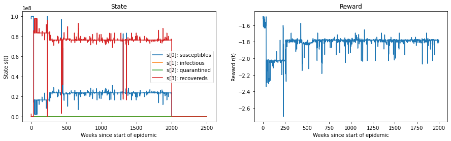

```python
subplot(R_states, R_rewards, "Random Agent")
subplot(D_states,D_rewards, "Deterministic Agent")
subplot(Q_states,Q_rewards, "Q-Learning Agent")
```

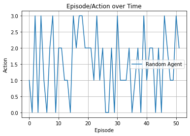

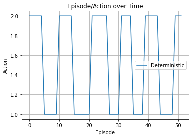

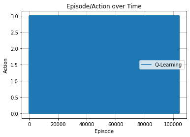

```python
def plot_action_stats(action,agent):

    # Plot the episode length over time
    fig1 = plt.figure(figsize=(6,4))
    plt.plot(action, label= agent)
    plt.xlabel("Episode")
    plt.ylabel("Action")
    plt.title("Episode/Action over Time", )
    plt.grid(True)
    plt.legend()
plot_action_stats(R_action, "Random Agent")
plot_action_stats(D_action,"Deterministic")
plot_action_stats(Q_action,"Q-Learning")
```

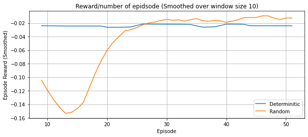

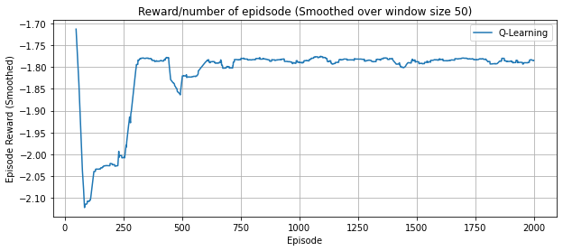

```python
# Episode reward over time for Deterministic and Random agents
def plot_episode_stats(stats1,stats2, smoothing_window):
    # Plot the episode reward over time

    fig2 = plt.figure(figsize=(10,4))
    rewards_smoothed1 = pd.Series(stats1).rolling(smoothing_window, min_periods=smoothing_window).mean()
    rewards_smoothed2 = pd.Series(stats2).rolling(smoothing_window, min_periods=smoothing_window).mean()
    plt.plot(rewards_smoothed1, label = 'Determinitic')
    plt.plot(rewards_smoothed2, label = 'Random')
    plt.xlabel("Episode")
    plt.ylabel("Episode Reward (Smoothed)")
    plt.title("Reward/number of epidsode (Smoothed over window size {})".format(smoothing_window))
    plt.grid(True)
    plt.legend()
plot_episode_stats(D_rewards,R_rewards, smoothing_window=10)

def plot_episode_stats_Q_learning(stats0,smoothing_window):
    # Plot the episode reward over time

    fig2 = plt.figure(figsize=(10,4))
    rewards_smoothed0 = pd.Series(stats0).rolling(smoothing_window, min_periods=smoothing_window).mean()

    plt.plot(rewards_smoothed0, label = 'Q-Learning')

    plt.xlabel("Episode")
    plt.ylabel("Episode Reward (Smoothed)")
    plt.title("Reward/number of epidsode (Smoothed over window size {})".format(smoothing_window))
    plt.grid(True)
    plt.legend()
plot_episode_stats_Q_learning(Q_rewards, smoothing_window=50)
```

# Section 3 functions for visualisations

> The code here is used to process the problem_id, the stochastic-ness or the noisy observation. It helps to reduce the repeatitiveness in the code below and these fucntions can be used for all 3 visualisations.

```python
## Repititive Code to process the following problems

def deterministic_ViRL(id, agent, stochastic=False, noisy=False):

  if stochastic:
    env = virl.Epidemic(stochastic=stochastic, noisy=noisy)
  else:
    env = virl.Epidemic(problem_id=id, noisy=noisy)
  states = []
  rewards = []
  actions = []
  done = False

  s = env.reset()
  states.append(s)
  while not done:
    action = agent(s)
    s, r, done, info = env.step(action=action)
    states.append(s)
    actions.append(action)
    rewards.append(r)

  return states,rewards,actions

def q_learning(id,stochastic=False, noisy=False, fn_model_in="q-learning.h5"):

  if stochastic:
    env = virl.Epidemic(stochastic=stochastic, noisy=noisy)
  else:
    env = virl.Epidemic(problem_id=id, noisy=noisy)

  d_states    = env.observation_space.shape[0]
  n_actions   = env.action_space.n

  alpha= 0.000001
  nn_config   = [64,64]
  BATCH_SIZE  = 64
  BUFFER_SIZE = 10000

  nn_func_approximator = NNFunctionApproximatorJointKeras(alpha, d_states, n_actions, nn_config)
  nn_func_approximator_target = NNFunctionApproximatorJointKeras(alpha, d_states, n_actions, nn_config)

  stats,Q_states,Q_action = q_learning_nn(env,nn_func_approximator, nn_func_approximator_target,num_episodes= 2000, max_steps_per_episode=52,
                      epsilon_init=0.1, epsilon_decay=0.9995, epsilon_min=0.01, fn_model_in="q-learning.tf")

  Q_rewards = stats[1]

  env.close()
  return Q_states,Q_rewards,Q_action
```

## 3.2 Determinitic ViRL problem

> In this section, you will evaluate all agents on a deterministic version of the ViRL environment.

> The Epidemic environment implements 10 deterministic epidemic problems, each with a different set of parameters. The specific problem simulated by an instance of Epidemic is specified in the constructor's `problem_id` parameter

> For example, to instanciate the problem 0, you can do `env = virl.Epidemic(problem_id=0)`

> Below is a code that plots the epidemic evolution when a dummy agent that always takes the same action is in charge.

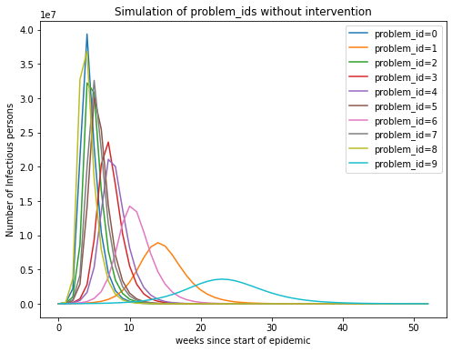

```python
fig, ax = plt.subplots(figsize=(8, 6))

# for all problem ID in [0:9]
for i in range(10):
    env = virl.Epidemic(problem_id=i)
    states = []
    rewards = []
    done = False

    s = env.reset()
    states.append(s)
    while not done:
        s, r, done, info = env.step(action=0) # dummy agent - no-intervention always
        states.append(s)
        rewards.append(r)
    # plot number of infectious persons each week from problem i
    ax.plot(np.array(states)[:,1], label=f'problem_id={i}')

ax.set_xlabel('weeks since start of epidemic')
ax.set_ylabel('Number of Infectious persons')
ax.set_title('Simulation of problem_ids without intervention')
ax.legend()
```

#### **Problem ID: 8**

> For the Determinitic ViRL problem ID, I choose ID 8 to evaluate all my agents on it. Problem ID depicts how it would have slighlty less ifectious persons as compared to id zero (at which our q-learning agent was initially trained).

> The total rewards are calculated after processing ID 8 for all 3 agents, the total rewards for determinictic agent was -1.285, for random agent it was -2.33 and the last reward for q-learning agent was -1.98. It can be seen how deterministic out performs the other two agents, and, apart from deterministic agent, q-learning agent report lower reward values as compared to initially run in section 2.

> The next bit, after calculating the total rewards, we plot graphs for the metrics which were used in 3.1. The graphs for state vs weeks and rewards vs weeks follow the same pattern as it did in the section 3.1 without any major change. Even the episode/action graphs and their patterns remains the same for the majority of the part for all three agents.

> The only difference we can observe is in the reward per number of episodes for q-learning agent where the agent takes around 1100 episodes to give an evidence of convergence. The graph depict, if more smoothed (to let's say 100), might give a straight line but from the current representation, the graph doesn't properly converge but does give an evidence of how if the agent was trained for a little over 2000 episodes it most probably would have converged with a straight line.

```python
R_states, R_rewards, R_action = deterministic_ViRL(8,random_agent)
D_states, D_rewards, D_action = deterministic_ViRL(8,deterministic_agent)
Q_states,Q_rewards,Q_action = q_learning(8)

print()
print("Random Agent rewards:",sum(R_rewards))
print("Deterministic Agent rewards:",sum(D_rewards))
print("Q-Learning rewards:",Q_rewards[-1])
```

```
episode: 1999/2000, score: 51, epsilon: 0.01
Random Agent rewards: -2.3342109338373547
Deterministic Agent rewards: -1.2808466282679358
Q-Learning rewards: -1.9845046722964137
```

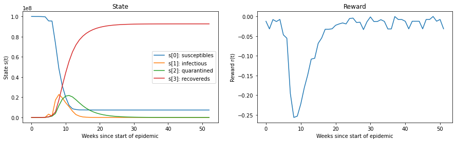

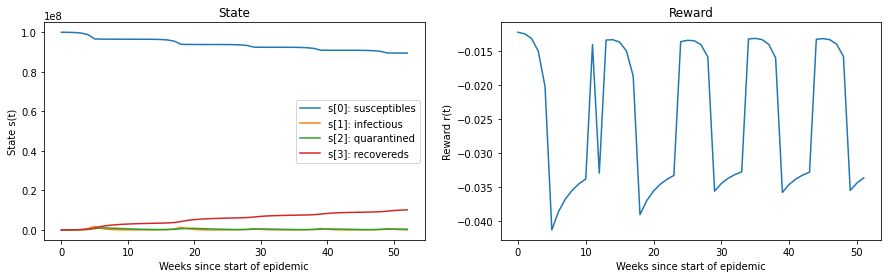

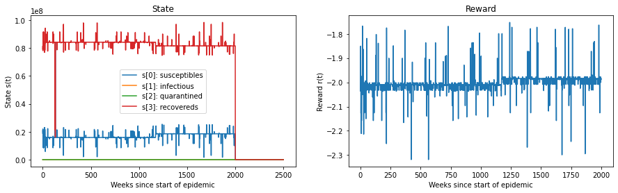

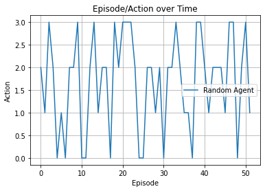

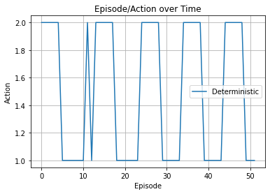

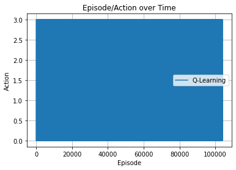

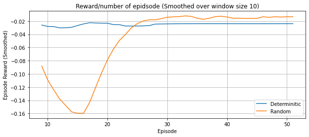

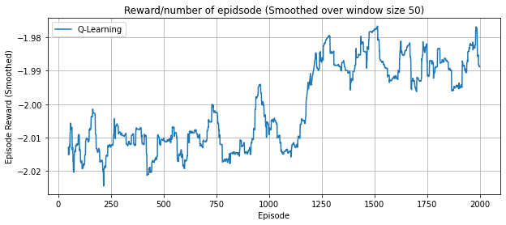

```python
# Subplots for every agent's rewards/performance in a years time
subplot(R_states, R_rewards, "Random Agent")
subplot(D_states,D_rewards, "Deterministic Agent")
subplot(Q_states,Q_rewards, "Q-Learning Agent")

# PLot for what action taken at what time of th year
plot_action_stats(R_action, "Random Agent")
plot_action_stats(D_action,"Deterministic")
plot_action_stats(Q_action,"Q-Learning")

#Episode reward over time for the three agents
plot_episode_stats( D_rewards,R_rewards, smoothing_window=10)
plot_episode_stats_Q_learning(Q_rewards,smoothing_window=50)
```

## 3.3 Determinitic ViRL problem with observational noise

> In this section, you will evaluate all agents on the same determinitis problem ViRL environment but with noisy observation. This is to simulate an imperfect measurement of the various population metrics that constitute the state of this system. Please reuse the same problem ID as in section 3.2 above.

> Independent observation noise on each timestep can be activated by setting the `noisy` flag in the constructor (`noisy=True`). The figure below illustrates one sequence of noisy observations, where no intervention (action=0) is performed.

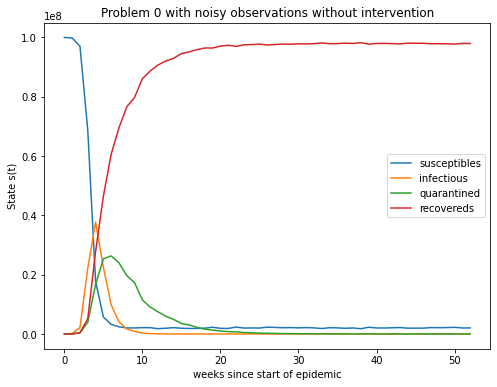

```python
# instanciante a virl env for problem ID 0 and with observational noise
env = virl.Epidemic(problem_id=0, noisy=True)

states = []
rewards = []
done = False

s = env.reset()
states.append(s)
while not done:
    s, r, done, info = env.step(action=0) # dummy agent
    states.append(s)
    rewards.append(r)

# plot the state evolution
fig, ax = plt.subplots(figsize=(8, 6))
labels = ['susceptibles', 'infectious', 'quarantined', 'recovereds']
states = np.array(states)
for i in range(4):
    ax.plot(states[:,i], label=labels[i]);
ax.set_xlabel('weeks since start of epidemic')
ax.set_ylabel('State s(t)')
ax.set_title('Problem 0 with noisy observations without intervention')
ax.legend()
```

> In this section we test evaluate our three agents upon adding noisy data. This will result in imperfect measurement of the various population metrics of the state of this system. We will use the same ID 8 to test our agents and to keep the randomness of the noise added to the population deterministic, I have added a function set_seed() which will use random.seed to set the random noise added to be the same upon each run. The simulation is ran 3 times as it takes nearly 1 hour for the for all the 3 simulations to run. Hence it wasn't optimal to run more than 3 in this case. For this section, we simulate our agents to run thrice and then calculate the mean rewards, and the standard deviation

> Followed by our statistical anaylsis, the graphs produced didn't show any unique varaition as compared to section 3.2 and 3.1 state vs week, rewards vs weeks and action per episode for all the agents. The random agent, though, shows a slight variation the reward vs weeks graph takes a downward spiral around 15 weeks and then goes up. This is a bit different as compared to other simulations where the downward drop in the graph appeared close to the 10th week for section 3.1 and 3.2. For random agent, the action per episode graph also denotes how action 3 becomes quite popular 20th week (there was no action 3 before that) which is different to the simulations in 3.1 and 3.2 where the actions are quite random and, apparently, equally distributed.

> Reward per number of episodes, the random and determinitic agent follow the same pattern as visualized in section 3.1 and 3.2 where random is converging at a higher reward than deterministic and deterministic is constant. As for the q-learning agent, the graph shows a lot of variation in the plot but follow an upward spiral 750 episodes and then reward value shows variation in a constant line till the 2000 episode. If the graph is smoothed to, let's say 100, it will show a straight line at the top, depicting it reaching convergence. The graph gives evidence of the agent looking for a good policy and reaching convergence and I believe if the agent is run a few more thousand episodes it will reach proper convergence at a higher reward value.

```python
def set_seed(seed, verbose=True):
    if verbose:
        print('Setting seed to {}'.format(seed))
    random.seed(seed)
    np.random.seed(seed)
set_seed(1)

R_reward = np.zeros(shape=(3,))
D_reward = np.zeros(shape=(3,))
Q_reward = np.zeros(shape=(3,))
for i in range(3):
  R_states, R_rewards, R_action = deterministic_ViRL(8,random_agent, noisy=True)
  D_states, D_rewards, D_action = deterministic_ViRL(8,deterministic_agent, noisy=True)
  Q_states,Q_rewards,Q_action = q_learning(8, noisy=True)

  R_reward[i] = sum(R_rewards)
  Q_reward[i] = Q_rewards[-1]
  D_reward[i] = sum(D_rewards)

print()
print("Mean Random Agent",np.mean(R_reward))
print("Mean Determinitic agent",np.mean(D_reward))
print("Mean Q-Learning",np.mean(Q_reward))
print()
print("Standard Deviation Random Agent",np.std(R_reward))
print("Standard Deviation Determinitic agent",np.std(D_reward))
print("Standard Deviation Q-Learning",np.std(Q_reward))
```

```
Setting seed to 1
episode: 1999/2000, score: 51, epsilon: 0.01
Mean Random Agent -2.2401170951837543
Mean Determinitic agent -1.2886936172355317
Mean Q-Learning -1.9845046722964137

Standard Deviation Random Agent 0.13400606729206826
Standard Deviation Determinitic agent 0.009605799250032451
Standard Deviation Q-Learning 0.0
```

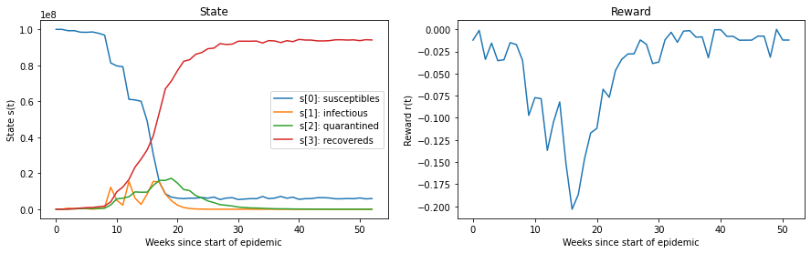

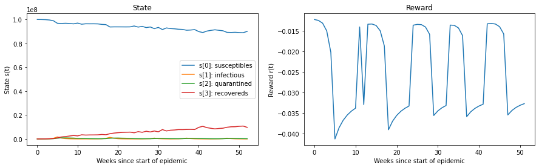

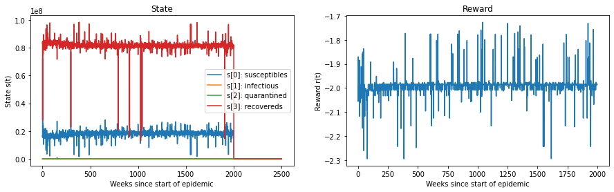

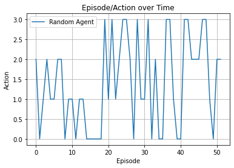

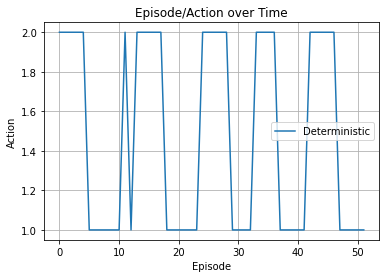

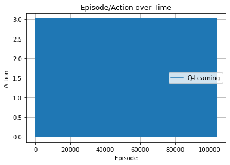

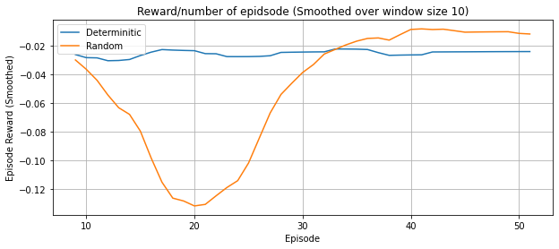

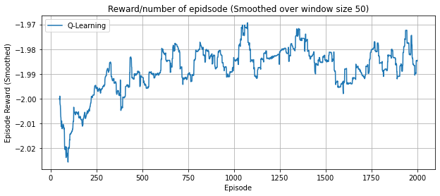

```python
# Subplots for every agent's rewards/performance in a years time
subplot(R_states, R_rewards, "Random Agent")
subplot(D_states,D_rewards, "Deterministic Agent")
subplot(Q_states,Q_rewards, "Q-Learning Agent")

# PLot for what action taken at what time of th year
plot_action_stats(R_action, "Random Agent")
plot_action_stats(D_action,"Deterministic")
plot_action_stats(Q_action,"Q-Learning")

#Episode reward over time for the three agents
plot_episode_stats( D_rewards,R_rewards, smoothing_window=10)
plot_episode_stats_Q_learning(Q_rewards,smoothing_window=50)
```

## 3.4 Stochastic ViRL problem with observational noise

> In this section, you will evaluate all agents on a stochastic version of the ViRL environment with noisy observation.

> A stochastic environment with different epidemic dynamics in each episode can be activated by setting the `stochastic` flag to `True` in the constructor. Each time, a new epidemic similation is generated with unique internal parameter values for population dynamics, viral infection, etc. This is intended to reflect the unknown elements when a new virus emerges.

> The code cell below illustrates how the number of infected persons varies across random draws if no intervention (action=0) is performed. This simulation also has the noisy flag to True. If `stochastic=True`, then problem_id is ignored.

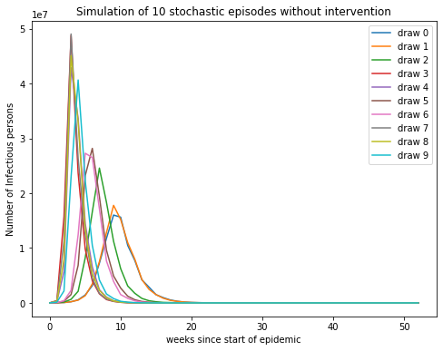

```python
fig, ax = plt.subplots(figsize=(8, 6))

# we run 10 simulation, each time the virl environment has different
# parameters due to the stochastic=True flag
for i in range(10):
    env = virl.Epidemic(stochastic=True, noisy=True)
    states = []
    rewards = []
    done = False
    s = env.reset()
    states.append(s)
    while not done:
        s, r, done, info = env.step(action=0) # dummy agent
        states.append(s)
        rewards.append(r)
    # plot the state evolution
    ax.plot(np.array(states)[:,1], label=f'draw {i}')

ax.set_xlabel('weeks since start of epidemic')
ax.set_ylabel('Number of Infectious persons')
ax.set_title('Simulation of 10 stochastic episodes without intervention')
ax.legend()
```

> As shown in the figure above, each of the 10 run of this simulation resulted in different epidemic dynamics.

> For this section 3.4, we'll evaluate our agents upon setting the stochastic flag to true along with adding noisy observation to our environment. Following the same pratice from section 3.3, we'll run our simulation 3 times, use the set_seed() function to determine the randomness of the stochasticness and noisy obeservation values and we start off by comparing the average rewards and the standard deviation between the reward values.

> As per the other metrics evaluated in the form of graphs, the state vs weeks and rewards per week doesn't show any diiference for Random agent as compared to other sections. For the deterministic agent, the graphs for the reward vs weeks rises smoothly from low to high and stays constant at the top which is quite a change for the deterministic agent. The Q-learning agent reports more variation in recovered and suspectibles in the state vs weeks graph also a lot of variabilty in the rewards vs weeks graph. For the action per episode graph, random agent randoml produces it's actions but whereas deterministic agent chooses action 2 each and everytime due to which it has a constant line at action equalling to 2. For q-learning it's the same as other sections apart from the slight difference how this time it favours action a bit less as we can see some white space in the graph.

> For the reward per number of episode graph, the deterministic agent position in the graph have risen very close to random agent whereas random agent still depicts the same behaviour. The q-learning agent, after some variations in rewards till 1250 episodes, successfully converges giving a constant line around reward -1.6. Our q-learning agent performs quite well and end up finding an optimal policy as compared to section 3.3 and 3.2.

```python
def set_seed(seed, verbose=True):
    if verbose:
        print('Setting seed to {}'.format(seed))
    random.seed(seed)
    np.random.seed(seed)
set_seed(1)

R_reward = np.zeros(shape=(3,))
D_reward = np.zeros(shape=(3,))
Q_reward = np.zeros(shape=(3,))
for i in range(3):
  R_states, R_rewards, R_action = deterministic_ViRL(8,random_agent, stochastic=True, noisy=True)
  D_states, D_rewards, D_action = deterministic_ViRL(8,deterministic_agent,stochastic=True ,noisy=True)
  Q_states,Q_rewards,Q_action = q_learning(8, stochastic=True ,noisy=True)

  R_reward[i] = sum(R_rewards)
  Q_reward[i] = Q_rewards[-1]
  D_reward[i] = sum(D_rewards)

print()
print("Mean Random Agent",np.mean(R_reward))
print("Mean Determinitic agent",np.mean(D_reward))
print("Mean Q-Learning",np.mean(Q_reward))
print()
print("Standard Deviation Random Agent",np.std(R_reward))
print("Standard Deviation Determinitic agent",np.std(D_reward))
print("Standard Deviation Q-Learning",np.std(Q_reward))
```

```
Setting seed to 1
episode: 1999/2000, score: 51, epsilon: 0.01
Mean Random Agent -2.219186029949927
Mean Determinitic agent -1.05737108993313
Mean Q-Learning -1.6337995427519356

Standard Deviation Random Agent 0.3022080240781166
Standard Deviation Determinitic agent 0.3314079902828128
Standard Deviation Q-Learning 2.4234397589355313e-06
```

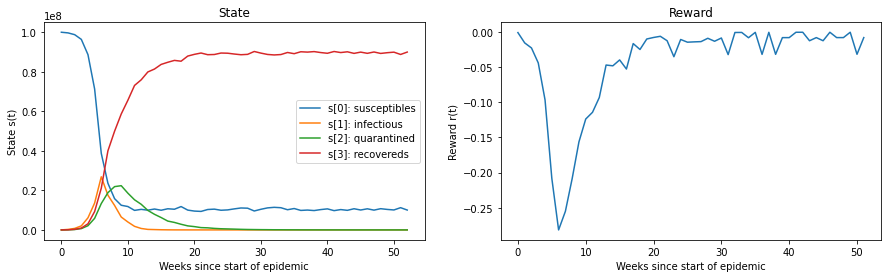

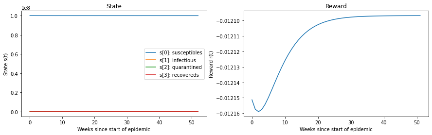

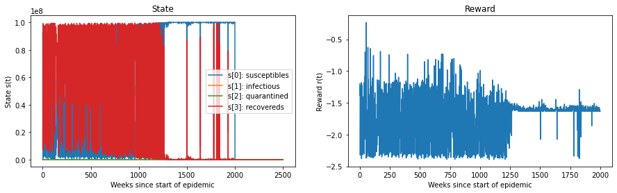

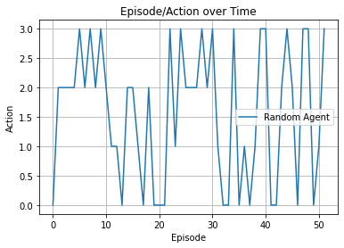

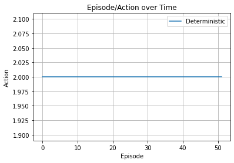

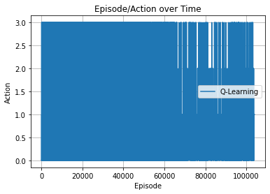

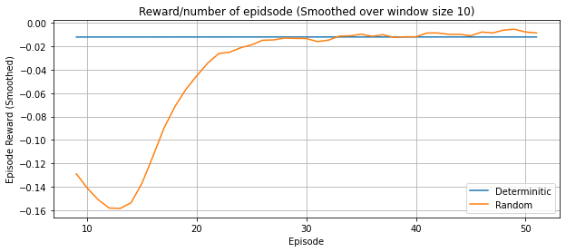

[figure not shown]

```python
# Subplots for every agent's rewards/performance in a years time
subplot(R_states, R_rewards, "Random Agent")
subplot(D_states,D_rewards, "Deterministic Agent")
subplot(Q_states,Q_rewards, "Q-Learning Agent")

# PLot for what action taken at what time of th year
plot_action_stats(R_action, "Random Agent")
plot_action_stats(D_action,"Deterministic")
plot_action_stats(Q_action,"Q-Learning")

#Episode reward over time for the three agents
plot_episode_stats( D_rewards,R_rewards, smoothing_window=10)
plot_episode_stats_Q_learning(Q_rewards,smoothing_window=100)
```

## 3.5 Improving generalization performance

> **Write code to update your Q-Learning with Function Approximation agent so it might generalize better on the stochastic problem with observational noise.**

> Couldn't do this part.

# 4. Real-world reflection

*Could the optimal policies you developed in this work be used to inform decision making by politicians?*

> The policies and the agents designed in this exercise were tested and avluated on different problem ID and metrics. For most of the problem IDs, the results varied and in many of them the agents weren't able to reach convergence (specifically talking about q-learning model). But in some problem ID, the agents were able to provide good policies and actions which kept the rate of infectious low and helped people survive for longer.

> When it comes to implementing those policies, there are several other factors that count rather than just knowing how good the policies could be. The COVID-19 virus has been unpredictable and it spreads at an abnormally fast rate effecting lots of people. Determinitic agent and Random agent can be proved to be effective or completely unaffective given the state of the situtation. My Q -learning agent, even though it is trained and optimised to converge at a low total reward, there is no guranttee for it to succceed given what kind of situtaion/problem is of crona at the current point.

> Moreover, to use and test such policies require lots of data and that data could only be collected after passing the steps of ethics protocol which to people can even disagree to give their approval. Apart from that, not all AI/ML algorithms have been sucessfull and proved to provide inaccurate statisitcs leading to unwanted results. Leaving the policies to be implemented at the hands of an AI is would too great of a risk which might not be welcomed by the poeple and, after all, who would take the responsibility if something goes wrong? The system? I don't think so.

> I understand politicians are interested in an self automated policies which can help them imlplement an algorithm enabling them impose the actions (such as the 4 actions suggested by the current ViRL environment) suitable to counter the situations. But as per the agents designed in this report, I believe they need to be further refined and optimized to be effective enough to make stratergies helping to counter the current problem.

# 5. Discussion

> Usual discussion style section. What did you learn? What are the limitations of your approach? What would you do differently?

> This project has been nothing less than wild ride. From taking couple of hours to design and understand random and deterministic agents to taking countless *days* to figure out the hyper parameter for q-learning model. This assessed exercise gave me the opportunity to understand was artificial intelligence is actually about. I had the chance to research plenty in Reinforcement learning to understand how the lab code works. I also got the chance to to see how changing hyper parameters affect our q-learning model to change and understand about the concept about convergence in q-learning model [2]. For instance, having a low batch-size enlables the q-model to train faster, and, for our enivronemnt, it needed a minimum of 2000 episodes to converge as compared to the lab 8 problem which required much less. The epsilon value and the learning rate had to be kept lower to make the our policy a bit less random and learn to find an optimal policy.

> However, I will still admit, I wasn't able to understand the whole wide concept of Q-learning which I surely plan to do so because I am guessing this concept would help me in my final year project.

> If I had enough time to work on this assessed exercise, I would prefer to build a q-model from scratch which would have enabled me tune the hyper parameter more conifdently and figure out a better policy. I would prefer to look into prioritised replay and double q-learning to greatly enhance the performance of my model to provide optimal results.

> Conclusively, according to evaluations carried out in section 3, the q-learning model of mine doesn't work optimally which I would have liked it to be, but, with a bit more effort, I am assure it can privode optimal results for majority of the problem ID for our environment. I got to learn a lot from this assessed exercise which was a good and hectic experience.

# ===EOF===

> This is a flag to tell the word counter to stop counting, anything in and below this cell will not be counted towards your report word count.

> Please do change this cell, any word below EOF does not count toward your report word count. Also please do not try to be snicky about the word counter; embrace the constraints we give you rather than fight them.

# References

> [1] Simple Reinforcement Learning: Q-learning https://towardsdatascience.com/simple-reinforcement-learning-q-learning-fcddc4b6fe56

> [2] Convergence of Reinforcement Learning Algorithms https://towardsdatascience.com/convergence-of-reinforcement-learning-algorithms-3d917f66b3b7

# Appendices

> The code for the Q-Learning is taken from lab 8 solution

# Exporting your report

> To simplify your life, we made an automatic script below to create your submission file.

> If you provide your student number and the sharing url for you colab notebook below, the last cell will do the following:
> 1. Generate a folder to save your report
> 2. Export this notebook as a .ipynb file
> 3. Convert and save this notebook as a static html page
> 4. Convert and save this notebook as a standalone pdf file
> 5. Create a html file that automatically redirect to your notebook sharing url
> 6. Create a .zip file with all these files
> 7. Downloading the .zip file to your default download folder

> You just have to check the result is good for you and submit the .zip file on Moodle before the deadline. Couldn't be any easier right?

> **Please make sure your word count is around 5000 and you have not more than 10 figures before submtting your report. You are expected to remove all instruction text given in this template (above the EOF section) from your final report so it is not counted toward your final world count.**

## Add information about you and your Colab notebook sharing URL

> First add your student number in the `YOUR_STUDENT_NUMBER` variable below.

> Then generate a sharing URL for this notebook. See https://www.tutorialspoint.com/google_colab/google_colab_sharing_notebook.htm and choose "Anyone with the link option".

> Finally, add your Colab sharing URL in the `SHARING_URL_FOR_THIS_COLAB` variable below.

```python
YOUR_STUDENT_NUMBER = "2403967"

# get a sharable link and copy it below
# See https://www.tutorialspoint.com/google_colab/google_colab_sharing_notebook.htm
# and choose "Anyone with the link option"
SHARING_URL_FOR_THIS_COLAB = "https://colab.research.google.com/drive/11kLrYafBBWchAgqcIDMTx2Cal1hoYx8L?usp=sharing"
```

> **If you are confused at this stage, watch the step-by-step video below**

```python
from IPython.display import YouTubeVideo
YouTubeVideo('JlcJ8FeEvvI', width=1120, height=630)
```

## Generate and export your files

> Well done! Now run the cell below and it will generate all the files you need for your submission

```python
# Exporting your submission files

###########################################
# !!!!!!!!!!!!!!!!!!!!!!!!!!!!!!!!!!!!!!!!!
# Please do not change this code cell in any way
# !!!!!!!!!!!!!!!!!!!!!!!!!!!!!!!!!!!!!!!!!
###########################################

# checking you did read the above cell and added your information
# again please be smart and add your information above rather than modifying the code below
STUDENT_CHANGED_DEFAULT_VALUES = True

# checking you entered a student number
if YOUR_STUDENT_NUMBER == "REPLACE_WITH_YOUR_STUDENT_NUMBER":
  STUDENT_CHANGED_DEFAULT_VALUES = False
  print("###########################################")
  print("")
  print("Please add your student number in the YOUR_STUDENT_NUMBER variable in the code cell above!")
  print("")
  print("###########################################")

# checking you entered a URL that works
if SHARING_URL_FOR_THIS_COLAB == "REPLACE_WITH_YOUR_SHARING_URL_FOR_THIS_COLAB" :
  STUDENT_CHANGED_DEFAULT_VALUES = False
  print("###########################################")
  print("")
  print("Please add your Colab sharing URL number in the `SHARING_URL_FOR_THIS_COLAB` variable in the code cell above!")
  print("")
  print("###########################################")

if not STUDENT_CHANGED_DEFAULT_VALUES:
  raise ValueError('You have not added you student number and/or shared the sharing URL for your Colab notebook. \n Please read the above cells carefully.')


# define some folder and file names
import os
report_foldername = "COMPSCI_4004_Coursework_{}".format(YOUR_STUDENT_NUMBER)
report_folderpath = os.path.join("/content", report_foldername)
ipynb_filename = os.path.join(report_folderpath, "report_{}.ipynb".format(YOUR_STUDENT_NUMBER))
html_redirect_filename = os.path.join(report_folderpath, "colab_link_{}.html".format(YOUR_STUDENT_NUMBER))
report_zip_filename = os.path.join(report_folderpath, "{}.zip".format(report_foldername))

# create folder if it does not exist
if not os.path.exists(report_folderpath):
  print("Creating {} folder...".format(report_folderpath))
  os.mkdir(report_folderpath)

# Obtain the notebook JSON as a string
print("Saving notebook as {}...".format(ipynb_filename))

from google.colab import _message
notebook_json = _message.blocking_request('get_ipynb', request='', timeout_sec=10)

# save ipynb part into a file locally
import json
with open(ipynb_filename, 'w') as f:
    f.write(json.dumps(notebook_json["ipynb"]))

# export to html
print("Exporting notebook as html file...")
os.system("jupyter nbconvert --to html {}".format(ipynb_filename))

#export to pdf
print("Exporting notebook as pdf file...")
## make sure xetex is installed
print("Installing required librarie, this might take a while, be patient...")
!apt-get -qq install texlive-xetex texlive-fonts-recommended texlive-generic-recommended > /dev/null
## export to pdf
os.system("jupyter nbconvert --to pdf {}".format(ipynb_filename))

# paste the url for this colab in a html file redirecting to it
print("Creating html redirecting file to your Colab...")

html_redirect_content = """
<!DOCTYPE HTML>
<html lang="en-US">
    <head>
        <meta charset="UTF-8">
        <meta http-equiv="refresh" content="0; url={colab_link}">
        <script type="text/javascript">
            window.location.href = "{colab_link}"
        </script>
        <title>Page Redirection</title>
    </head>
    <body>
        <!-- Note: don't tell people to `click` the link, just tell them that it is a link. -->
        If you are not redirected automatically, follow <a href='{colab_link}'>{colab_link}</a>.
    </body>
</html>
""".format(colab_link=SHARING_URL_FOR_THIS_COLAB)

with open(html_redirect_filename, 'w') as f:
    f.write(html_redirect_content)

# # zip the folder with all results
print("Making a zip file of the all thing...")
os.system("cd {}; zip -r {} *".format(report_folderpath, report_zip_filename))

# download the zip folder for submission
print("Downloading the zip file to your computer...")

from google.colab import files
files.download(report_zip_filename)

#
print("")
print("All done! Check and submit the downloaded zip file")
```